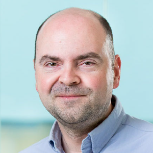

# Oliver Hofmann

## Bio

Bioinformatician with an interest in large-scale genomics, with an emphasis on workflows, national infrastructure and interoperability standards to support the use of genomic data in transforming clinical approaches to cancer care.

## Education

**University of Cologne** | Cologne, Germany

2004 | Doctor of Science in Biochemistry

1999 | Diploma in Biology

## Experience

#### **University of Melbourne**

*Melbourne, Victoria, Australia*

2022 - Present | Professor, Department of Clinical Pathology

2016 - 2022 | Associate Professor, Department of Clinical Pathology

2016 - Present | Head of Bioinformatics, Collaborative Centre for Genomic Cancer Medicine

#### **University of Glasgow**

*Glasgow, UK*

2015 - 2016 | Reader, Institute of Cancer Sciences

2015 - 2016 | Head of Bioinformatics, Wolfson-Wohl Cancer Research Centre

#### **Harvard T.H. Chan School of Public Health**

*Boston, MA, USA*

2015 - 2016 | Visiting Associate Professor | Department of Biostatistics

2014 - 2015 | Director | Bioinformatics Core

2012 - 2014 | Senior Research Scientist | Department of Biostatistics

2010 - 2012 | Research Scientist | Department of Biostatistics

2008 - 2014 | Associate Director | Bioinformatics Core

2008 - 2009 | Research Associate | Department of Biostatistics

2007 - 2008 | Research Fellow | Department of Biostatistics

#### **South African National Bioinformatics Institute**

*Cape Town, South Africa*

2005 - 2007 | Post-doctoral Researcher

#### **deCODE genetics**

*Reykjavik, Iceland*

2001 - 2002 | Visiting Researcher

## Professional Activities

**Australian Genomics** | Co-lead Data Management Program | Building re-usable national infrastructure

**Global Alliance for Genomics and Health (GA4GH)** | Co-lead Large Scale Genomics Workstream | Strategic Leadership Committee

**GA4GH National Initiatives Forum** | Steering Committee

**Garvan Institute of Medical Research** | Data Science Steering Committee

**European Genomics Data Infrastructure (GDI)** | Infrastructure Advisory Board